# ALY6070: Cryptocurrency Prices and Valuations: Bitcoin

Week1

Group 7

2023-03-06

[figure not shown]

## Load libraries

```r
my_packages = c("plyr", "plotly", "ggplot2", "psych", "tidyr", "tidyverse","dplyr","lubridate","readr","caret")
#install.packages(my_packages)
lapply(my_packages, require, character.only = T)
```

[output not shown]

[output not shown]

# PART 1: Select your Dataset

## Load dataset

```r
#Dataset used from https://coinmetrics.io/community-network-data/
bitcoin <- read.csv("/Users/abidikshit/R_Projects/Data/coin_Bitcoin.csv", header = T)
cat("Number of Rows before cleanup:", nrow(bitcoin), "\n") # Printing string and variable row count on the same line
```

```
## Number of Rows before cleanup: 2991
```

```r
cat("Number of Columns before cleanup:", ncol(bitcoin), "\n")
```

```
## Number of Columns before cleanup: 10
```

```r
cat("Blank cells count before cleanup:", sum(!complete.cases(bitcoin))) # Displaying Blank Cells Count for uncleaned data
```

```
## Blank cells count before cleanup: 0
```

## Convert date column to Date format

```r
bitcoin$Date <- as.Date(bitcoin$Date)
```

```r
headTail(bitcoin, top = 4, bottom = 4, ellipsis = F)
```

|  | SNo | Name | Symbol | Date | High | Low | Open | Close | Volume | Marketcap |
| --- | --- | --- | --- | --- | --- | --- | --- | --- | --- | --- |
| 1 | 1 | Bitcoin | BTC | 2013-04-29 | 147.49 | 134.00 | 134.44 | 144.54 | 0 | 1603768864 |
| 2 | 2 | Bitcoin | BTC | 2013-04-30 | 146.93 | 134.05 | 144.00 | 139.00 | 0 | 1542813125 |
| 3 | 3 | Bitcoin | BTC | 2013-05-01 | 139.89 | 107.72 | 139.00 | 116.99 | 0 | 1298954594 |
| 4 | 4 | Bitcoin | BTC | 2013-05-02 | 125.60 | 92.28 | 116.38 | 105.21 | 0 | 1168517495 |
| 2988 | 2988 | Bitcoin | BTC | 2021-07-03 | 34909.26 | 33402.70 | 33854.42 | 34668.55 | 24383958643 | 649939701346 |
| 2989 | 2989 | Bitcoin | BTC | 2021-07-04 | 35937.57 | 34396.48 | 34665.56 | 35287.78 | 24924307911 | 661574836315 |
| 2990 | 2990 | Bitcoin | BTC | 2021-07-05 | 35284.34 | 33213.66 | 35284.34 | 33746.00 | 26721554282 | 632696207200 |
| 2991 | 2991 | Bitcoin | BTC | 2021-07-06 | 35038.54 | 33599.92 | 33723.51 | 34235.19 | 26501259870 | 641899161594 |

```r
summary(bitcoin)
```

```
##       SNo             Name              Symbol               Date
##  Min.   :   1.0   Length:2991        Length:2991        Min.   :2013-04-29
##  1st Qu.: 748.5   Class :character   Class :character   1st Qu.:2015-05-16
##  Median :1496.0   Mode  :character   Mode  :character   Median :2017-06-02
##  Mean   :1496.0                                         Mean   :2017-06-02
##  3rd Qu.:2243.5                                         3rd Qu.:2019-06-19
##  Max.   :2991.0                                         Max.   :2021-07-06
##       High               Low                Open             Close
##  Min.   :   74.56   Min.   :   65.53   Min.   :   68.5   Min.   :   68.43
##  1st Qu.:  436.18   1st Qu.:  422.88   1st Qu.:  430.4   1st Qu.:  430.57
##  Median : 2387.61   Median : 2178.50   Median : 2269.9   Median : 2286.41
##  Mean   : 6893.33   Mean   : 6486.01   Mean   : 6700.1   Mean   : 6711.29
##  3rd Qu.: 8733.93   3rd Qu.: 8289.80   3rd Qu.: 8569.7   3rd Qu.: 8576.24
##  Max.   :64863.10   Max.   :62208.96   Max.   :63523.8   Max.   :63503.46
##      Volume            Marketcap
##  Min.   :0.000e+00   Min.   :7.784e+08
##  1st Qu.:3.037e+07   1st Qu.:6.306e+09
##  Median :9.460e+08   Median :3.742e+10
##  Mean   :1.091e+10   Mean   :1.209e+11
##  3rd Qu.:1.592e+10   3rd Qu.:1.500e+11
##  Max.   :3.510e+11   Max.   :1.186e+12
```

# PART 2: Explore your data features with different types of graphs in R

## Now, let’s create different types of graphs to explore the data features:

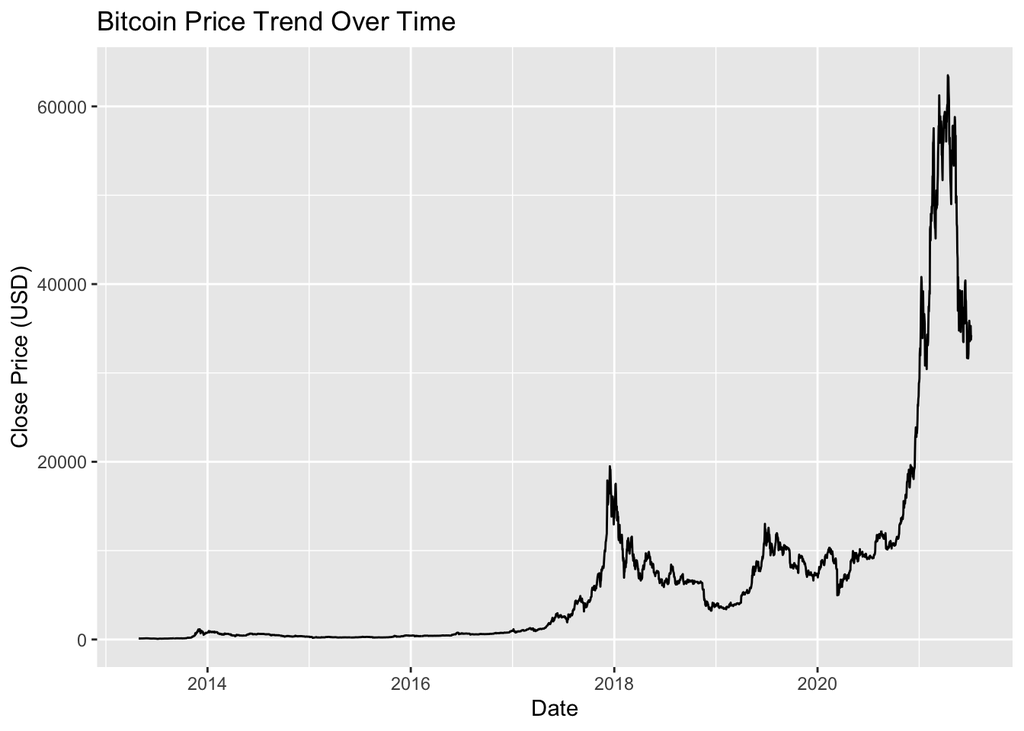

```r
ggplot(bitcoin, aes(x = Date, y = Close)) + geom_line() + xlab("Date") + ylab("Close Price (USD)") + ggtitle("Bitcoin Price Trend Over Time")
```

## Histogram - to show the distribution of Bitcoin closing prices:

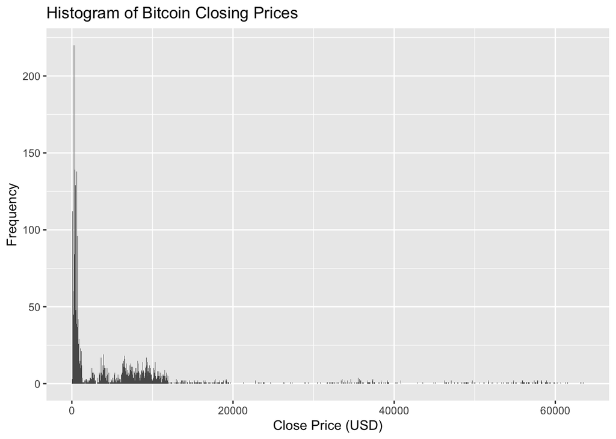

```r
ggplot(bitcoin, aes(x = Close)) + geom_histogram(binwidth = 50) + xlab("Close Price (USD)") + ylab("Frequency") + ggtitle("Histogram of Bitcoin Closing Prices")
```

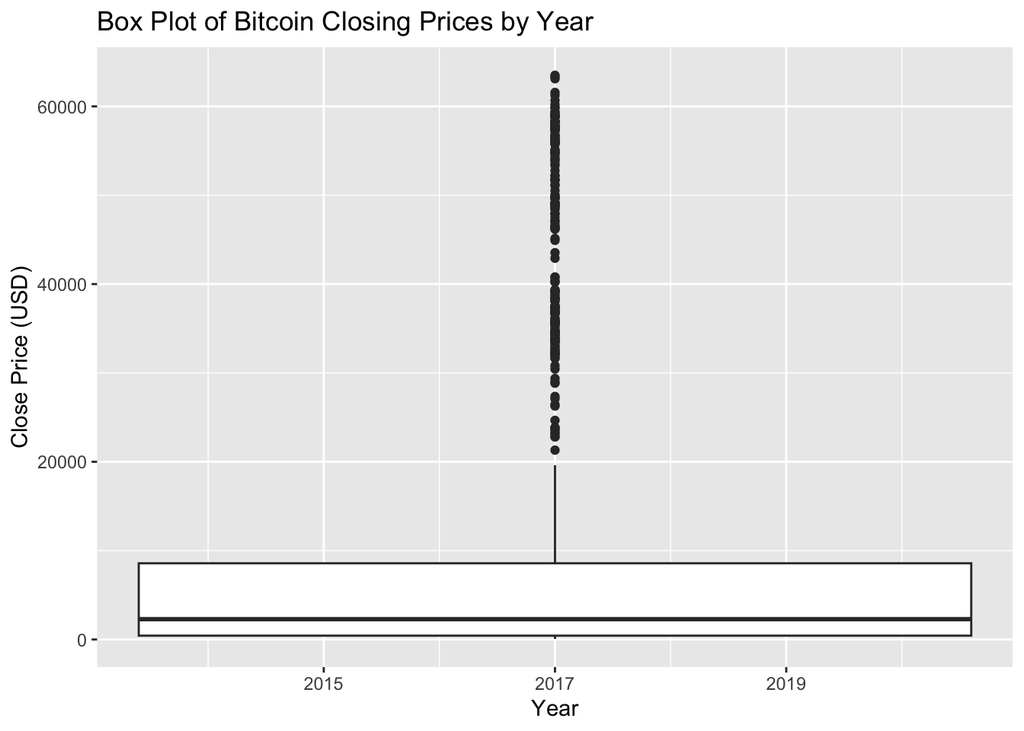

```r
bitcoin$Year <- year(bitcoin$Date)
ggplot(bitcoin, aes(x = Year, y = Close)) + geom_boxplot() + xlab("Year") + ylab("Close Price (USD)") + ggtitle("Box Plot of Bitcoin Closing Prices by Year")
```

## Scatter plot - to show the relationship between Bitcoin closing prices and trading volume:

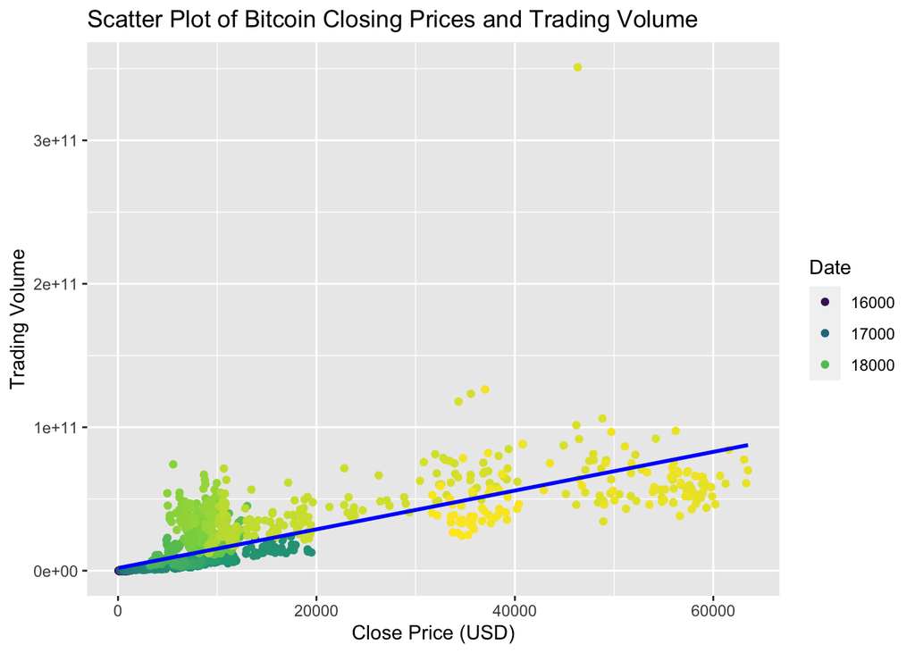

```r
ggplot(bitcoin, aes(x = Close, y = Volume, colour = Date)) +
  geom_point() +
  xlab("Close Price (USD)") +
  ylab("Trading Volume") +
  ggtitle("Scatter Plot of Bitcoin Closing Prices and Trading Volume") +
  scale_color_viridis_c() +
  guides(colour = guide_legend(title = "Date")) +
  geom_smooth(method="lm", se=FALSE, color="blue")
```

## Bar chart - to show the total trading volume of Bitcoin by year:

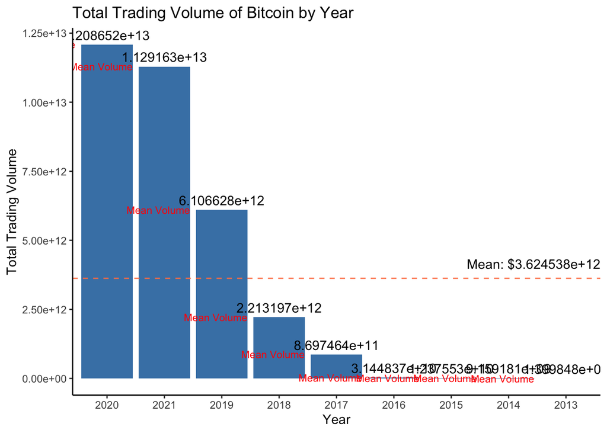

```r
total_volume <- aggregate(Volume ~ Year, data = bitcoin, sum)
mean_volume <- mean(total_volume$Volume)

ggplot(total_volume, aes(x = reorder(Year, -Volume), y = Volume)) +
  geom_bar(stat = "identity", fill = "steelblue") +
  xlab("Year") +
  ylab("Total Trading Volume") +
  ggtitle("Total Trading Volume of Bitcoin by Year") +
  geom_text(aes(label = format(Volume, big.mark = ",")), vjust = -0.5) +
  geom_hline(yintercept = mean_volume, linetype = "dashed", color = "coral") +
  annotate("text", x = Inf, y = mean_volume, vjust = -1, hjust = 1, label = paste0("Mean: $", format(mean_volume, big.mark = ","))) +
  geom_text(aes(label = "Mean Volume"), hjust = 1.5, color = "red", size = 3) +
  theme_classic()
```

#PART 3:Run a PCA approach in R to do a feature reduction

## Let’s run a Principal Component Analysis (PCA) approach in R to do a feature reduction on the cryptocurrency price history dataset.First, let’s load the dataset and prepare it for PCA. We will use the dataset, and select only the Open, High, Low, Close, Volume, and Marketcap columns:

```r
bitcoin_pca <- read_csv("/Users/abidikshit/R_Projects/Data/coin_Bitcoin.csv", col_types = cols_only(Date = col_date(), Open = col_double(), High = col_double(), Low = col_double(), Close = col_double(), Volume = col_double(), Marketcap = col_double()))
bitcoin_pca <- bitcoin_pca[,c(2:7)]
```

## Next, we will scale the data to have zero mean and unit variance:

```r
scaled_bitcoin <- scale(bitcoin_pca)
```

## Now, we can run the PCA using the prcomp() function:

```r
pca_bitcoin <- prcomp(scaled_bitcoin, scale = TRUE)
```

## We can now explore the results of the PCA, starting with the summary of the PCA object:

```r
summary(pca_bitcoin)
```

```
## Importance of components:
##                           PC1    PC2     PC3     PC4     PC5     PC6
## Standard deviation     2.3857 0.5521 0.04500 0.03276 0.01892 0.01157
## Proportion of Variance 0.9486 0.0508 0.00034 0.00018 0.00006 0.00002
## Cumulative Proportion  0.9486 0.9994 0.99974 0.99992 0.99998 1.00000
```

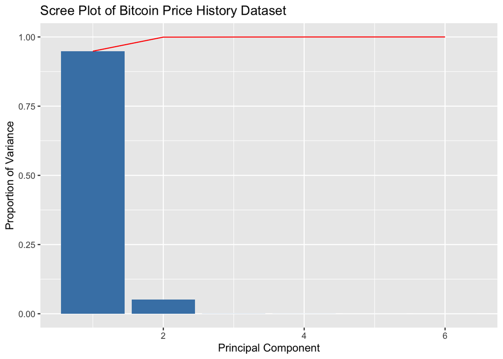

```r
scree_plot <- ggplot(data.frame(PC = 1:6, Variance = pca_bitcoin$sdev^2 / sum(pca_bitcoin$sdev^2)), aes(x = PC, y = Variance)) + geom_bar(stat = "identity", fill = "steelblue") + geom_line(aes(x = PC, y = cumsum(Variance)), color = "red") + xlab("Principal Component") + ylab("Proportion of Variance") + ggtitle("Scree Plot of Bitcoin Price History Dataset")
scree_plot
```

## Finally, we can extract the principal components using the predict() function:

## We can then use these principal components for further analysis or modeling.

```r
pcs_bitcoin <- predict(pca_bitcoin, scaled_bitcoin)
```

## Plot the cumulative variance plot

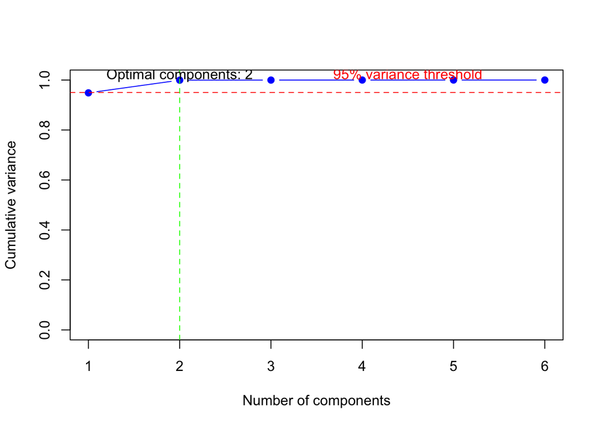

```r
# Create the cumulative variance plot
cumulative_variance <- cumsum(pca_bitcoin$sdev^2 / sum(pca_bitcoin$sdev^2))
plot(cumulative_variance, xlab = "Number of components", ylab = "Cumulative variance",
     type = "b", pch = 19, col = "blue", ylim = c(0,1))

# Add a dashed line at the 95% variance threshold
abline(h = 0.95, lty = 2, col = "red")

# Add a vertical line at the optimal number of components
optimal_components <- which.max(cumulative_variance >= 0.95)
abline(v = optimal_components, lty = 2, col = "green")

# Add text labels for the variance threshold and optimal number of components
text(optimal_components, 0.97, paste0("Optimal components: ", optimal_components), pos = 3)
text(length(cumulative_variance)*0.75, 0.97, "95% variance threshold", pos = 3, col = "red")
```

```r
# Choose the number of components
n_components <- length(which(cumsum(pca_bitcoin$sdev^2 / sum(pca_bitcoin$sdev^2)) < 0.8)) + 1
cat("Number of components:", n_components, "\n")
```

```
## Number of components: 1
```

## References

Wood (2021, December 14);Silge (n.d.)

Silge, M. K. A. J. n.d. *16 Dimensionality Reduction | Tidy Modeling with r*. https://www.tmwr.org/dimensionality.html.

Wood, R. 2021, December 14. *Learn Principal Component Analysis in r - Towards Data Science*. https://towardsdatascience.com/learn-principle-component-analysis-in-r-ddba7c9b1064.

## Appendix

```r
my_packages = c("plyr", "plotly", "ggplot2", "psych", "tidyr", "tidyverse","dplyr","lubridate","readr","caret")
#install.packages(my_packages)
lapply(my_packages, require, character.only = T)

#Dataset used from https://coinmetrics.io/community-network-data/
bitcoin <- read.csv("/Users/abidikshit/R_Projects/Data/coin_Bitcoin.csv", header = T)
cat("Number of Rows before cleanup:", nrow(bitcoin), "\n") # Printing string and variable row count on the same line
cat("Number of Columns before cleanup:", ncol(bitcoin), "\n")
cat("Blank cells count before cleanup:", sum(!complete.cases(bitcoin))) # Displaying Blank Cells Count for uncleaned data

bitcoin$Date <- as.Date(bitcoin$Date)

headTail(bitcoin, top = 4, bottom = 4, ellipsis = F)

summary(bitcoin)

ggplot(bitcoin, aes(x = Date, y = Close)) + geom_line() + xlab("Date") + ylab("Close Price (USD)") + ggtitle("Bitcoin Price Trend Over Time")

ggplot(bitcoin, aes(x = Close)) + geom_histogram(binwidth = 50) + xlab("Close Price (USD)") + ylab("Frequency") + ggtitle("Histogram of Bitcoin Closing Prices")

bitcoin$Year <- year(bitcoin$Date)
ggplot(bitcoin, aes(x = Year, y = Close)) + geom_boxplot() + xlab("Year") + ylab("Close Price (USD)") + ggtitle("Box Plot of Bitcoin Closing Prices by Year")

ggplot(bitcoin, aes(x = Close, y = Volume, colour = Date)) +
  geom_point() +
  xlab("Close Price (USD)") +
  ylab("Trading Volume") +
  ggtitle("Scatter Plot of Bitcoin Closing Prices and Trading Volume") +
  scale_color_viridis_c() +
  guides(colour = guide_legend(title = "Date")) +
  geom_smooth(method="lm", se=FALSE, color="blue")

total_volume <- aggregate(Volume ~ Year, data = bitcoin, sum)
mean_volume <- mean(total_volume$Volume)

ggplot(total_volume, aes(x = reorder(Year, -Volume), y = Volume)) +
  geom_bar(stat = "identity", fill = "steelblue") +
  xlab("Year") +
  ylab("Total Trading Volume") +
  ggtitle("Total Trading Volume of Bitcoin by Year") +
  geom_text(aes(label = format(Volume, big.mark = ",")), vjust = -0.5) +
  geom_hline(yintercept = mean_volume, linetype = "dashed", color = "coral") +
  annotate("text", x = Inf, y = mean_volume, vjust = -1, hjust = 1, label = paste0("Mean: $", format(mean_volume, big.mark = ","))) +
  geom_text(aes(label = "Mean Volume"), hjust = 1.5, color = "red", size = 3) +
  theme_classic()


bitcoin_pca <- read_csv("/Users/abidikshit/R_Projects/Data/coin_Bitcoin.csv", col_types = cols_only(Date = col_date(), Open = col_double(), High = col_double(), Low = col_double(), Close = col_double(), Volume = col_double(), Marketcap = col_double()))
bitcoin_pca <- bitcoin_pca[,c(2:7)]

scaled_bitcoin <- scale(bitcoin_pca)

pca_bitcoin <- prcomp(scaled_bitcoin, scale = TRUE)

summary(pca_bitcoin)

scree_plot <- ggplot(data.frame(PC = 1:6, Variance = pca_bitcoin$sdev^2 / sum(pca_bitcoin$sdev^2)), aes(x = PC, y = Variance)) + geom_bar(stat = "identity", fill = "steelblue") + geom_line(aes(x = PC, y = cumsum(Variance)), color = "red") + xlab("Principal Component") + ylab("Proportion of Variance") + ggtitle("Scree Plot of Bitcoin Price History Dataset")
scree_plot

pcs_bitcoin <- predict(pca_bitcoin, scaled_bitcoin)

# Create the cumulative variance plot
cumulative_variance <- cumsum(pca_bitcoin$sdev^2 / sum(pca_bitcoin$sdev^2))
plot(cumulative_variance, xlab = "Number of components", ylab = "Cumulative variance",
     type = "b", pch = 19, col = "blue", ylim = c(0,1))

# Add a dashed line at the 95% variance threshold
abline(h = 0.95, lty = 2, col = "red")

# Add a vertical line at the optimal number of components
optimal_components <- which.max(cumulative_variance >= 0.95)
abline(v = optimal_components, lty = 2, col = "green")

# Add text labels for the variance threshold and optimal number of components
text(optimal_components, 0.97, paste0("Optimal components: ", optimal_components), pos = 3)
text(length(cumulative_variance)*0.75, 0.97, "95% variance threshold", pos = 3, col = "red")


# Choose the number of components
n_components <- length(which(cumsum(pca_bitcoin$sdev^2 / sum(pca_bitcoin$sdev^2)) < 0.8)) + 1
cat("Number of components:", n_components, "\n")

## NA
```